# Información espacial en formato raster en R

# Visualizacion avanzada

Para generar visualizaciones más avanzadas podemos utilizar otros paquetes como `ggplot2` o `tmap`. Aquí veremos un ejemplo de cada uno.

## ggplot2

En ggplot se puede determinar directamente el color y relleno de cada capa vectorial. En este ejemplo se carga la biblioteca viridis para usar dicha escala de color.

```r
library(viridis)
```

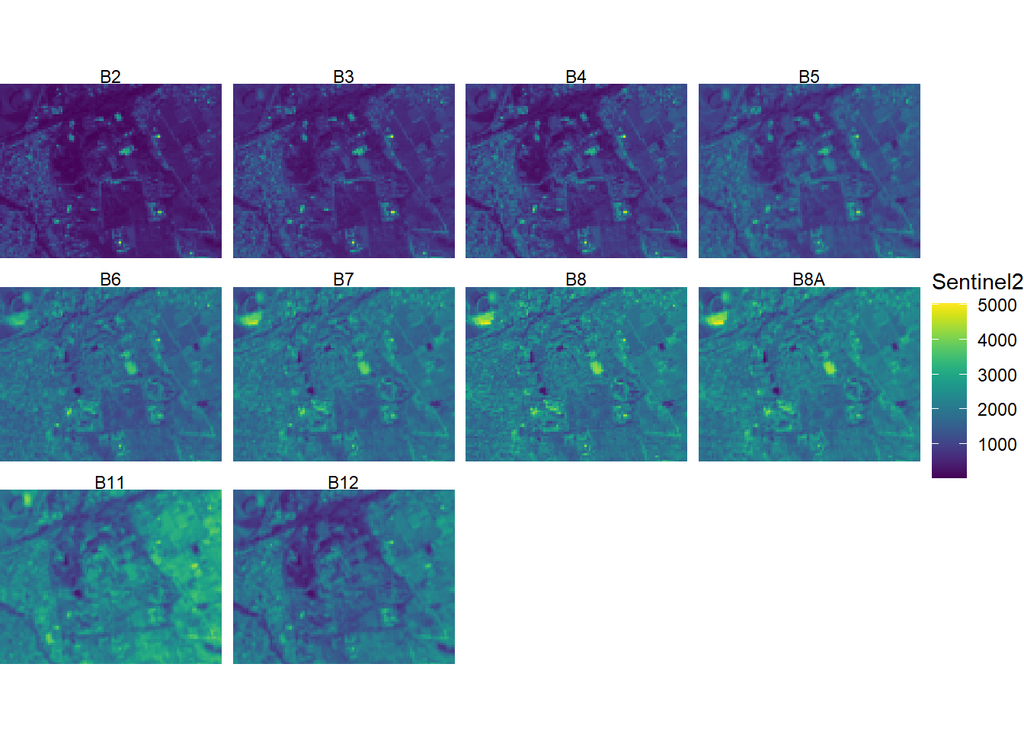

```r
## Loading required package: viridisLite
ggplot() +
  geom_stars(data = im1) +
  coord_equal() +
  facet_wrap(~band) +
  theme_void() +
  scale_fill_viridis() +
  scale_x_discrete(expand = c(0, 0)) +
  scale_y_discrete(expand = c(0, 0))
```

## tmap

La opción de tmap require de utilizar algún atributo de la información para determinar el color de relleno de cada polígono de acuerdo a los valores de ese atributo. Es similar a `ggplot` utilizando la opción de `aes`. Podemos ver algunas de las paletas que ya vienen pre hechas tanto para ggplot como para tmap con `tmaptools::palette_explorer()`

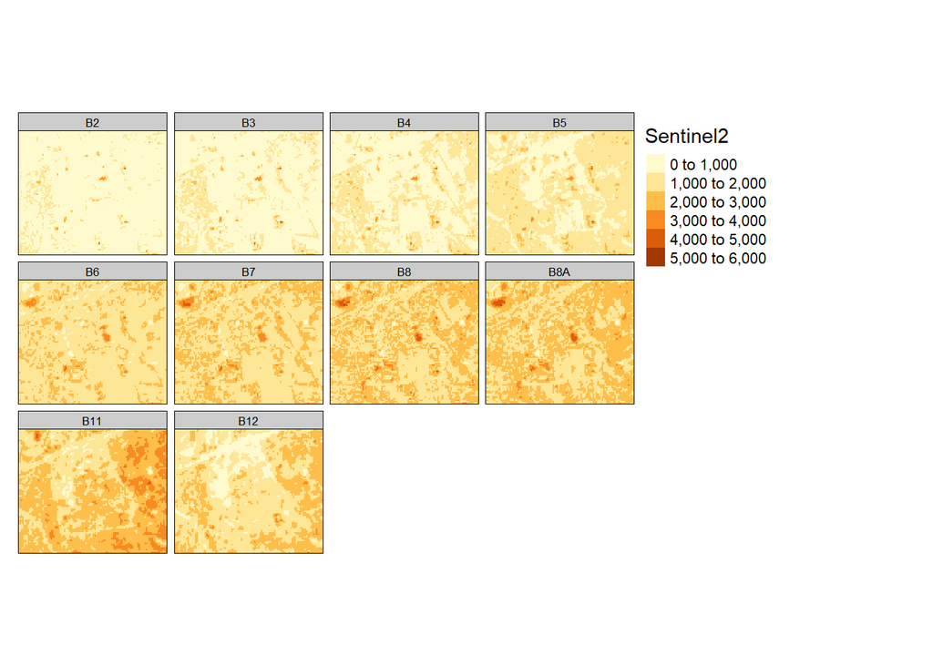

```r
library(tmap)

# Cargar shapr
tm_shape(im1) +
  # Elegir forma de visualización
  tm_raster()
```